# Final Paper

STOR 320.01 Group 17

April 26, 2022

# INTRODUCTION

Beginning in 1914, filmmaking exploded with the rise of independant film distributors – more than 4,200 new films were created that year. American filmmaking grew rapidly over the next century, catering to a diverse market that crosses racial, ethnic and political lines. In 1930, more than 65% of Americans saw a movie at least once a week. Movies have become a dominant part of American and international leisure time (Croteau et al. 2021).

In our research, we focused on the top 1000 highest grossing hollywood films. As a technology of entertainment, movies are not just attractive images; they are a result of an industry driven by market forces (Croteau et al. 2021). All of the pieces of a movie are carefully and purposefully designed, including the title, runtime, and genre. Movies and movie genres perform differently in different regions, and these elements are closely related to the ultimate profits of the film.

The two research questions discussed in this paper are:

1. How do different genres and combinations of genres influence the preference ratio of domestic sales over total sales of movies?
2. Is there a difference in the international and domestic preference of movie attributes?

Movies have various genres, including: action, comedy, family, science fiction, and romance. Different countries have their own styles and areas of expertise in the film industry; Japan and Thailand are famous for their thriller movies, while the United States is definitely leading the world in science fiction films. Furthermore, some other variables such as the **budget**, **minutes**, **month**, and **imdb_score** also have a great influence on how well a movie performs. These factors piqued our curiosity about the consistency of **international** and **domestic sales**. These questions can help us understand the disparity between domestic and international preference.

Advertising and exporting films globally requires a large investment, and sometimes the return on those investments are low. This research can help filmmakers and decide where and how to advertise their films based on the attributes of the film. A better understanding of the preferences of certain populations can help people in the film industry make wise investment decisions. With the results of this research, we can help the movie industry maximize profits and allow consumers better access to movies that interest them the most

# DATA

While the overall premise of our data is easy to understand, how it was compiled and added together gives it a layer of complexity. The data we used was compiled by Sanjeet Singh Naik, a student at the KJ Somaiya College of Engineering in India. The data itself has been scraped from multiple movie rating sources, including IMDb and Rotten Tomatoes. The dataset contains information about the top 1000 highest grossing Hollywood films and their specific production and rating stats, and is up to date as of January this year.

We then merged our original 1000 movie dataset with another dataset entitled “IMDb ratings for 5000 movies” using title as the key. This new data was compiled by Dinesh Sonachalam, a Software Developer at Gogoair, and was scraped directly from the IMDb website. We performed this operation so that we would be able to see the IMDb ratings for the selected movies and have a metric to measure popularity by.  
To answer our two questions, we narrowed down the variables in the data set instead of focusing on all of them.

The table below lists the relevant variables for the first 10 movies in the data set, with each row representing the statistics and information for a single movie. To start off with the categorical variables, these included **Title**, **Month** and **Genre**. For the purpose of our question, **Genre** was an especially important variable and it included 16 different categories ranging from Action to Romance. The **Month** variable displays whether the movie was release in the Winter, Spring, Summer, or Autumn. The **Title** allowed us to look at the words and length of the title. In terms of quantitative variables, the specific variables we looked at were **Year**, **Dom**, **Intl**, **IMDb**, and **Budget**. **Dom** and **Intl** represents the domestic sales and international sales respectively in million dollars. The **IMDb** gives the movie an overall rating out of ten, and these ratings are averaged from the votes of all IMDb users. Lastly, **Budget** represents the money allotted for the movie, and includes production, advertising, marketing, and other miscellaneous costs, in million dollars.

### Head of Movie Dataset

| Title | Month | Year | Budget | IMDb | Dom | Intl | Genre |
| --- | --- | --- | --- | --- | --- | --- | --- |
| Avatar | Winter | 2009 | 237.0 | 7.9 | 760.5 | 2086.7 | ['Action', 'Adventure', 'Fantasy', 'Sci-Fi'] |
| Titanic | Winter | 1997 | 200.0 | 7.7 | 659.4 | 1542.3 | ['Drama', 'Romance'] |
| Jurassic World | Summer | 2015 | 150.0 | 7.0 | 652.4 | 1018.1 | ['Action', 'Adventure', 'Sci-Fi'] |
| The Avengers | Spring | 2012 | 220.0 | 8.1 | 623.4 | 895.5 | ['Action', 'Adventure', 'Sci-Fi'] |
| The Avengers | Spring | 2012 | 220.0 | 8.1 | 623.4 | 895.5 | ['Action', 'Adventure', 'Sci-Fi'] |
| The Lion King | Summer | 2019 | 45.0 | 8.5 | 543.6 | 1119.3 | ['Adventure', 'Animation', 'Drama', 'Family', 'Musical'] |
| The Dark Knight | Summer | 2008 | 185.0 | 9.0 | 534.9 | 471.1 | ['Action', 'Crime', 'Drama', 'Thriller'] |
| Star Wars: Episode I - The Phantom Menace | Spring | 1999 | 115.0 | 6.5 | 474.5 | 552.5 | ['Action', 'Adventure', 'Fantasy', 'Sci-Fi'] |
| Star Wars: Episode IV - A New Hope | Spring | 1977 | 11.0 | 8.7 | 461.0 | 195.8 | ['Action', 'Adventure', 'Fantasy', 'Sci-Fi'] |
| Avengers: Age of Ultron | Spring | 2015 | 250.0 | 7.5 | 459.0 | 943.8 | ['Action', 'Adventure', 'Sci-Fi'] |

Other non-central variables include **total sales**, **minutes**, **movie info**, and **distributors**. **total sales** is particularly interesting as it gives us the opportunity to learn about the ratio of domestic to international sales for specific movies. **minutes** indicates how long the movie ran for, and we modified this variable so that all the values were represented in minutes. The **movie info** provided a brief paragraph introduction to each movie and the **distributor names** listed out which company was responsible for the marketing of the film. We did not include these variables in the table because they were not as relevant in answering our two questions.

To answer our questions, we created several variables in the data set. We created a **ratio** variable to represent the proportion of domestic sales over total sales. We also created the **Month** variable from the original data about release date. We used the factor function to make a month a factor variable with four values: spring, summer, autumn, and winter to refer to the season the movies were released. We denoted December to February as winter, March to May as spring, June to August as summer, and September to November as autumn. Finally, we created **log_domestic** and **log_international** to have the log value of movie sales because we wanted to predict sales with linear models. We also created 16 indicator variables from the **Genre** variable. These variables noted which genres each movie belongs to.

Our data visualization figure, shown below, describes differences in distribution of **international sales** and **domestic sales**, displayed in millions of dollars. The distribution is generally the same for both categories, but their values vary greatly. The sky blue line shows the **domestic sales**, which is much higher than **international sales** from around $100 million to $200 million in sales, and then drops below **international sales** from around $300 million through $1 billion in sales. The darker blue line represents **international sales**, which are more evenly spread than **domestic sales**.

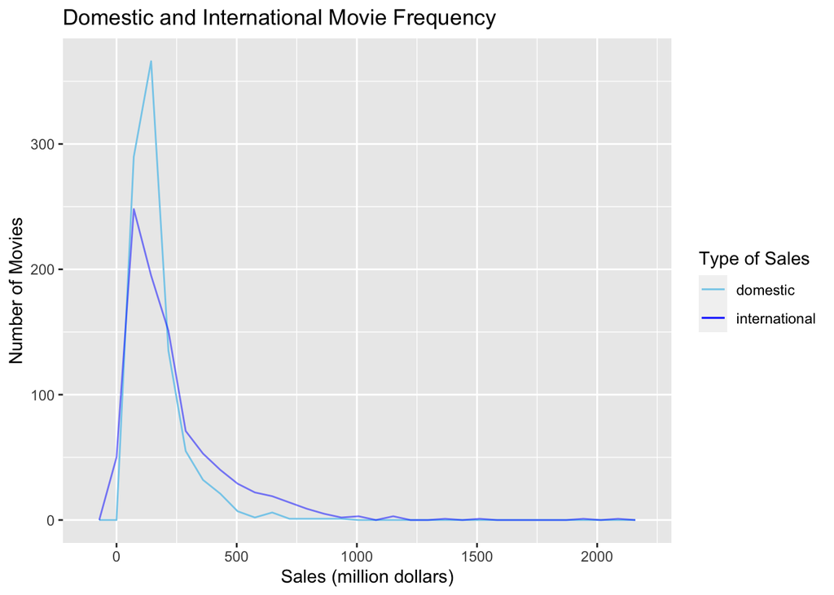

# RESULTS

### **First Question**

The first question we have is how different genres and combinations of genres influence the proportion of **domestic sales** over **total sales** of the movies in our dataset. To work on this question, we subsetted the dataset to include only movies with certain genres, and then generated the 95% confidence intervals of the proportion of **domestic sales** over **total sales** (we will refer to this variable as **ratio** in the following context) by calculating means and standard errors of the ratio for each movie genre. We first made a graph of the confidence intervals for the 16 genres as shown below. The x-intercept of the red dashed line represents the overall average ratio, which is 0.4859805. From this process, we found that some genres had significantly larger or smaller ratios than the average, with their confidence intervals lying completely left of the vertical line (which represents the overall average). This finding means they performed better outside of America than the average movie in our dataset. Other confidence intervals include the average, and some lie completely to the right of the average.

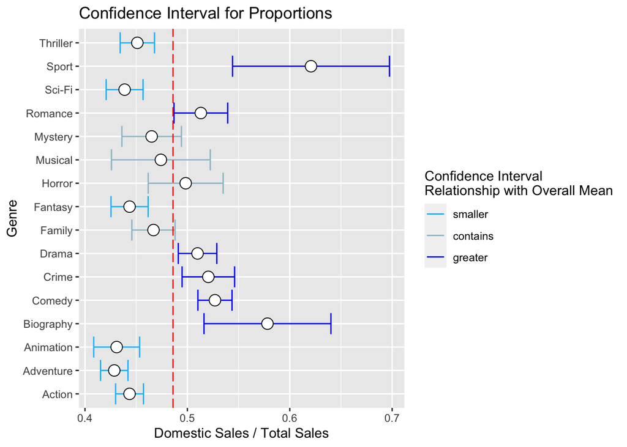

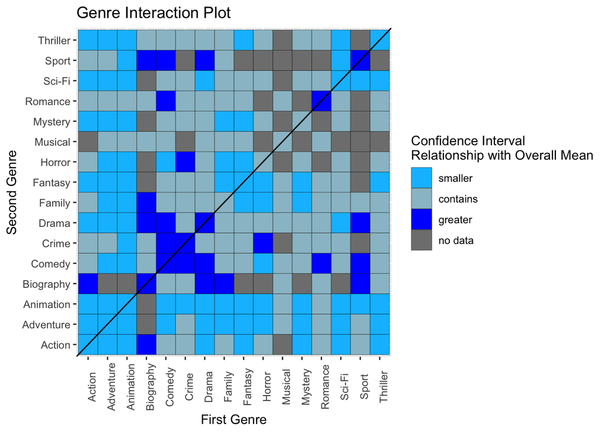

### Model Comparison Table

| model | RMSE | variables |
| --- | --- | --- |
| Linear Model | 0.377558 | 23 |
| Linear Model with 8 Chosen Variables | 0.369275 | 8 |
| Best Subset | 0.357635 | 14 |
| Cross Validation Best Subset | 0.370540 | 3 |
| Lasso | 0.374777 | 4 |
| Lasso with Interaction | 0.363771 | 11 |

### Coefficient Comparison Table

| Variable | Domestic_model | International_model |
| --- | --- | --- |
| (Intercept) | 18.7275 | 18.7162 |
| Action | -0.0809 | -0.0685 |
| Adventure | 0.1491 | 0.3129 |
| `Sci-Fi` | 0.0932 | 0.0000 |
| Fantasy | 0.1161 | 0.0649 |
| Animation | -0.0880 | 0.2673 |
| Musical | 0.1176 | 0.2528 |
| Drama | -0.0559 | -0.1290 |
| Mystery | -0.1133 | 0.0000 |
| Biography | -0.0913 | -0.4469 |
| monthSummer | 0.0778 | 0.0981 |
| monthSpring | 0.1045 | 0.1115 |
| minutes | 0.0402 | 0.1324 |
| budget | 0.1258 | 0.3418 |
| imdb_score | 0.1507 | 0.1819 |
| Romance | 0.0000 | 0.1824 |
| Family | 0.0000 | -0.0164 |
| Comedy | 0.0000 | -0.1770 |
| Crime | 0.0000 | -0.0924 |
| Thriller | 0.0000 | 0.1180 |
| Sport | 0.0000 | -0.6849 |
| monthAutumn | 0.0000 | 0.0925 |
| year | 0.0000 | 0.0759 |

# CONCLUSION

The first question of our group project is: How do different genres and combinations of genres influence the proportion of domestic sales over total sales of movies? We subsetted the dataset to look at confidence intervals of proportions and compared them with the overall mean proportion. Some intervals lie completely to the right, others lie completely to the left, and some contain the average. Then we subsetted the data to look at confidence intervals of proportions for movies with two genres and again compared them with the overall mean. The result revealed that the relationship between confidence intervals and the overall mean for almost all genres changed when they are paired with different genres. This tells us that different combinations of genres greatly influence the proportion of domestic sales over total sales. Preferences of domestic and international audiences change greatly for different pairs of genres.

There are always more ways to perfect our modeling to produce the most accurate data. One way to effectively do this is to increase our sample size. Our sample size of 1,000 movies is enough to produce valid data, but it is certainly not enough for professional data analysis. Moreover, our data includes the 1,000 movies with the highest domestic sales, which will skew the data in favor of movies that are preferred in America. If the sales per movie were more randomized, we could have more accurate data analysis conclusions. When we were calculating the confidence intervals of movies with different combinations of genres, some intervals were not accurate due to the limited size of the sample. If we had access to data that could allow us to increase our data set to 5,000 movies, that would make our data and modeling more precise. Another method that we could incorporate would be inflation. Especially when comparing sales between movies from 1970 to 2019, there is certainly a difference in the amount each ticket is worth over the years. A profit of $50 million in 1970 would be worth closer to $370 million in 2019. To improve this, we need to compare the average movie ticket price for each year and use that as a reference of our sales data. Further, we have been using IMDB scores found online to predict both domestic and international sales. However, IMDB is a website open to audiences from all over the world. While there might be some differences between opinions from America and other countries, using global rating scores might be inappropriate on this occasion. To improve our data, we could use a more centralized review system such as a particular professional film critic’s numeric review.

Lastly, we cannot evaluate the popularity or success of movies solely based on sales. There are many factors that go into the sales of a movie: expectation, advertising, release date, the director, the leading actors and actresses, the producer, etc. Sales of a movie do not show the whole story of whether a movie is popular or successful. Thus, we should consider more variables and methods in order to better convey what movies are able to yield success. One way would be to compare the rate of sales over the movie budget. For instance, we can create a variable to represent the percentage of net income made by the movies. This would convey if a movie is more successful than another in a different way. Assessing success in a few different ways and then comparing those successes could help us determine which movies are overall most successful. A production company with a significantly smaller budget than another company could produce a movie with smaller sales but this does not necessarily mean the bigger budget movie is more successful – the smaller budget movie could have a much higher profit margin. Another improvement we could include would be incorporating the interaction variables for the genre variables. This would create more accurate data when we use the model to predict sales. However, we cannot include the interaction variables in ‘Best Subset’ because it would result in too much calculation for R. It would be beneficial to look at this dataset or a similar one with more powerful data analysis technology in order to see a fuller picture of the success of Hollywood movies.